# Project4: Volcano Eruption Visualization

# Part1: Getting the data

# Part2: Population within 100 km and at risk during volcanic eruptions

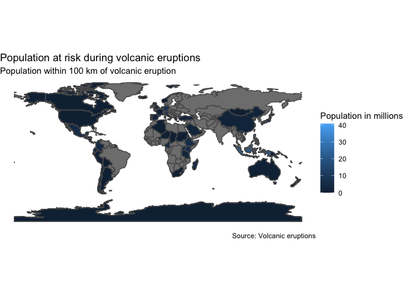

Looking at the above figure from Part 2, we could see that population in some countries from South America and Africa, countries like Malaysia, Indonesia and Philipines have populations in the range 10-30 million which could be at risk due to volcanic eruptions.

# Part3: Population within 100 km and at risk due to recent volcanic eruptions in year 2020

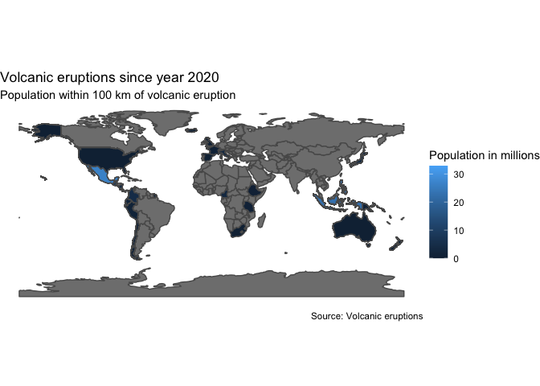

Looking at the above figure from Part 3, we could see that there are population within 100km of volcanic erupted during 2020. Some region from North America and countries like Malaysia, Indonesia and Philippines,which could be at risk due to volcanic eruptions. The color of the graph shows the range of populations, 10-30 million in those regions

# Part4: Frequency of causes for volcanic events

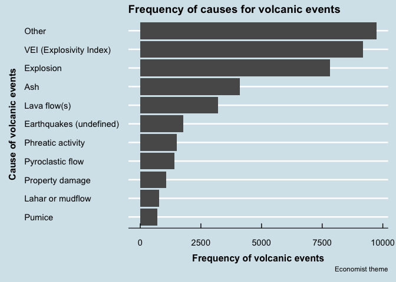

Looking at the above figure from Part 4, lot of miscellaneous reasons (others), higher VEI (explosivity index) and explosions dominate the causes for volcanic eruptions. Researchers still need to find and take into account multiple causes bundled up as miscellaneous reasons (others). This will help in prediction of probability for rare volcanic events.

# Part5: How long have the volcanic eruptions continued ?

| volcano_name | eruption_number | start_year | end_year | duration_year |
| --- | --- | --- | --- | --- |
| Stromboli | 13425 | 1558 | 1857 | 299 |
| Fogo | 13128 | 1500 | 1761 | 261 |
| Yasur | 15355 | 1774 | 2020 | 246 |
| Sangay | 11647 | 1728 | 1916 | 188 |
| Santa Maria | 10626 | 1922 | 2020 | 98 |
| Dukono | 16577 | 1933 | 2020 | 87 |
| Stromboli | 13435 | 1934 | 2020 | 86 |
| Sangay | 11648 | 1934 | 2011 | 77 |
| Kilauea | 10063 | 1823 | 1894 | 71 |
| Galeras | 11352 | 1670 | 1736 | 66 |

Looking at the above table for Part 5, Volcanoes named Stromboli, Fogo and Yasur have continued erupting for 200-300 years.

# Part6: Has the same volcano eurpted again. If so, how many times ?

| Volcano | Count |
| --- | --- |
| Etna | 241 |
| Fournaise, Piton de la | 194 |
| Asosan | 186 |
| Villarrica | 164 |
| Asamayama | 147 |
| Katla | 132 |
| Klyuchevskoy | 111 |
| Mauna Loa | 110 |
| Merapi | 110 |
| Izu-Oshima | 108 |

Looking at the above table for Part 6, Volcanoe named Etna has eruped more than 200 times, it is indeed a super active volcano. Something for Sicilian, italian and european people to watch out for.

# Part7: Bubble plot for volcanic eruptions ?

[figure not shown]

# Part8: Plotting moving average for sulphur concentration in the atmosphere ?

```
## Importing fonts may take a few minutes, depending on the number of fonts and the speed of the system.
## Continue? [y/n]
```

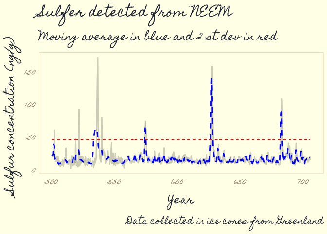